# Thinking the `SpaDES` way

Alex M Chubaty & Eliot McIntire

September 14, 2016

# 1 `SpaDES`

**Spa**tial **D**iscrete **E**vent **S**imulator

- [Discrete event simulators](https://en.wikipedia.org/wiki/Discrete_event_simulation) have a long history in computer science
- `SpaDES` is oriented around the construction of spatially explicit models and the use of **spatial** data.
- **events** describe *changes in the state of a complex system* at some *time*
- **time** is not modeled in a continuous fashion (simple loops would do this); we can ‘skip ahead’ to the next event, speeding up model evaluation
- events are scheduled (added to a queue) dynamically, and executed at their scheduled time

# 2 Other DESs

- In Ecology, there are other generic DESs:
  - SELES (very generic)
  - HexSim
  - NetLogoR (Individual based models)
- More specific DESs
  - LANDIS (forest dynamics)

# 3 Events

- Spring thaw

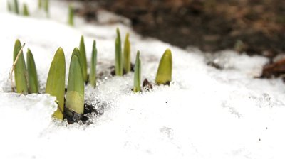

- Brainstorm events…

# 4 Modules

- Modules are a *convenient* way to group events that fit naturally together:
  - *E.g.*, fire ignition module
  - *E.g.*, carbon accumulation module
  - *E.g.*, data preparation module
- What is contained in one module is highly idiosyncratic .

# 5 Modules → Modularity

`SpaDES` is implemented in a way that facilitates *modularity* of code:

- different (ecological) processes can be grouped into logical units (*modules*)
- a(n) (ecological) model consists of a collection of modules
- each module is responsible for scheduling its own events
- modules interact *indirectly* via shared data objects (*e.g.*, a map); module ‘A’ doesn’t need to know what module ‘B’ is doing

**Thus, modules can be added, removed, or swapped out without needing to recode the rest of the model.**

# 6 Module types

- There are many types of modules that may be useful
  - Agents
  - Events
  - Data preparation
  - Summaries of data
  - see list from [SpaDES wiki](https://github.com/PredictiveEcology/SpaDES/wiki/Getting-Started-Guide#types-of-modules)
- Once we see that a module is just a convenient way to group together events, anything can be a module
- Can be 1 lines of code or as large as you want

# 7 Agent-based modules

- caribou
- [wolfAlps](https://github.com/PredictiveEcology/SpaDES-modules/blob/master/modules/wolfAlps/wolfAlps.R)
- Mountain Pine Beetle

# 8 Raster module

- Vegetation change
- Spatial clustering (*e.g.*, to create polygons)
- Aging
- Class change (*e.g.*, land cover class)
- Biomass change
- etc.

# 9 Data preparation module

- cropReprojectLcc

# 10 Why use a `SpaDES` module

… instead of just an R script or function?

- allows things to be scheduled
- allows modularity
  - a module can be reused by someone else with little change
- can be published on the web
- can estimate unknown parameters
- and much more…

# 11 Anatomy of a module

A module is an **R script** with 3 parts:

1. **Metadata** - a list of 15 things
   - Name, Author, Description, other for human reader
   - parameters, input objects, output objects for R to “understand”
2. **doEvent** - 2 types of things here
   - schedule events
   - run functions
3. **Anything else**
   - custom functions
   - initial data preparation steps

# 12 Running `SpaDES`

Essentially 2 steps

1. Create a `simList` using `simInit()`
2. Run `spades()`

All the necessary information is contained within the `simList`

What might be needed for a DES to run…

# 13 What is in the `simList`

```
- start and stop times
- data
- paths
- which modules to use
- parameters
- a schedule of events
- outputs
```

- Will be covered in detail [next](http://Rpubs.com/PredictiveEcology/Archives-Sept16-03-getting-technical)

# 14 Data

- We are working with R, so we can use any data structure or file format that R can understand
- `SpaDES` has some helpers for loading data, but in general, the module should be explicit
  - *e.g.*, downloadData(“caribouMovement”, path = tempdir())
- A module takes input data, changes them, and provides outputs
- like a function, but with the addition of “time”
- Some challenges …

# 15 Data challenges

Numerous challenges exist with data

- messy
- ownership
- large
- permissions
- errors
- other

`SpaDES` doesn’t necessarily solve these issues, but in some cases it helps.

# 16 Where to get help

- package help docs (*e.g.*, [overview of `SpaDES` package](http://www.rdocumentation.org/packages/SpaDES/versions/1.2.0/topics/SpaDES-package)):
- package vignettes ([link](https://github.com/PredictiveEcology/SpaDES/wiki/Help-Vignettes))
- `SpaDES` wiki ([link](https://github.com/PredictiveEcology/SpaDES/wiki/))
- `SpaDES` user group ([link](https://groups.google.com/d/forum/spades-users))
- bug reports ([link](https://github.com/PredictiveEcology/SpaDES/issues/))